# test_d_mannose_capsules_prod_model

### КРОК 1: Агрегація та консолідація історичних даних

1. **Визначення та Валідація Шляхів:** Динамічний пошук папок 'Single Pack' та 'Double Pack'.
2. **Вилучення Констант:** Зчитування фінансових констант (COGS, FBA Fee, Ref Fee Rate) з файлу `Product Cost Info.xlsx`.
3. **Агрегація:** Збір помісячних даних з усіх CSV-файлів, об'єднання Total та B2B метрик.
4. **Розрахунок:** Обчислення `Product Costs` та `Net Profit` для обох паків.
5. **Консолідація:** Створення фінальної зведеної таблиці (`df_comparison_pivot`), яка містить лише спільні місяці для коректного порівняння Single Pack та Double Pack.

**На виході:** Створено DataFrame `df_comparison_pivot`, готовий для розрахунку цільових KPI (c1, c2, c3, DR) на наступному етапі.

```
--- СЕРВІСНА ІНФОРМАЦІЯ ДЛЯ ЗВІРКИ ---
Аналізований Продукт: D-Mannose Capsules
Назва продукту: D-Mannose
Коренева директорія продукту: /Users/radyslav/data_analysis/Amazon/prod_perc_dpack
--------------------------------------------------
Шлях Single Pack: /Users/radyslav/data_analysis/Amazon/prod_perc_dpack/D-Mannose Capsules/D-Mannose 120 Capsules (Single Pack)
ASIN Single Pack: B0D322YRQY
Кількість файлів Single Pack: 6
Кількість рядків, оброблених по всім CSV, Single Pack: 9
Показники констант юніт економіки Single Pack: COGS: 4.44, FBA Fee: 3.90, Ref Rate: 15.00%
--------------------------------------------------
Шлях Double Pack: /Users/radyslav/data_analysis/Amazon/prod_perc_dpack/D-Mannose Capsules/D-Mannose 240 Capsules (Double Pack)
ASIN Double Pack: B0DQQCWY6T
Кількість файлів Double Pack: 5
Кількість рядків, оброблених по всім CSV, Double Pack: 7
Показники констант юніт економіки Double Pack: COGS: 7.38, FBA Fee: 4.15, Ref Rate: 15.00%
--------------------------------------------------
Місяці, що не є спільними для Single Pack та Double Pack: March_2025
--------------------------------------------------

--- ЗВЕДЕНА ТАБЛИЦЯ: Історичні Показники SP vs DP ---
```

| Month_Year Pack_Type Metric | April_2025 Single Pack | April_2025 Double Pack | May_2025 Single Pack | May_2025 Double Pack | June_2025 Single Pack | June_2025 Double Pack | July_2025 Single Pack | July_2025 Double Pack | August_2025 Single Pack | August_2025 Double Pack |
| --- | --- | --- | --- | --- | --- | --- | --- | --- | --- | --- |
| Sessions | 11845.00 | 1255.00 | 14038.00 | 1580.00 | 9473.00 | 1109.00 | 16315.00 | 1716.00 | 20046.00 | 1880.00 |
| Units Ordered | 4431.00 | 570.00 | 5277.00 | 754.00 | 3839.00 | 660.00 | 5890.00 | 881.00 | 7306.00 | 851.00 |
| Ordered Product Sales | 96231.11 | 18077.60 | 109974.16 | 24126.40 | 83492.16 | 21106.00 | 123644.30 | 30725.80 | 146627.74 | 31388.60 |
| Product Costs | 51389.21 | 9283.74 | 60506.30 | 12312.58 | 44541.08 | 10775.70 | 67669.24 | 14766.80 | 82926.20 | 14520.32 |
| Net Profit | 44841.90 | 8793.86 | 49467.86 | 11813.82 | 38951.08 | 10330.30 | 55975.06 | 15959.00 | 63701.54 | 16868.28 |
| Actual Price | 21.72 | 31.72 | 20.84 | 32.00 | 21.75 | 31.98 | 20.99 | 34.88 | 20.07 | 36.88 |

**Розраховані KPI:**

1. **DP_DR** (Discount Rate): Фактична знижка DP.
2. **DP_CR** (Conversion Rate): Конверсія продажів DP (Units DP / Sessions DP).
3. **DP_TAR** (Traffic Attraction Rate): Коефіцієнт залучення трафіку DP (Sessions DP / Sessions SP).
4. **DP_CSC** (Cross-Sell Conversion): Крос-продажна конверсія (Units DP / Sessions SP).
5. **DP_NPS** (Net Profit Share): Частка чистого прибутку DP від загального прибутку (DP / (SP + DP)).
6. **DP_NPPS** (Net Profit Per Session DP): Чистий прибуток на одну сесію DP.
7. **DP_CSPPS** (Cross-Sell Profit Per Session SP): Чистий прибуток DP на одну сесію SP.

**Вивід:**

```
--- СЕРВІСНА ІНФОРМАЦІЯ: Коефіцієнти Кореляції (DP_DR vs KPI) ---
Коефіцієнт DP_DR та DP_CR кореляції: 0.3972
Коефіцієнт DP_DR та DP_TAR кореляції: 0.8536
Коефіцієнт DP_DR та DP_CSC кореляції: 0.6134
Коефіцієнт DP_DR та DP_NPS кореляції: -0.5493
Коефіцієнт DP_DR та DP_NPPS кореляції: -0.4730
Коефіцієнт DP_DR та DP_CSPPS кореляції: 0.0934
--------------------------------------------------

--- ЗВЕДЕНА ТАБЛИЦЯ: Помісячні KPI ---
```

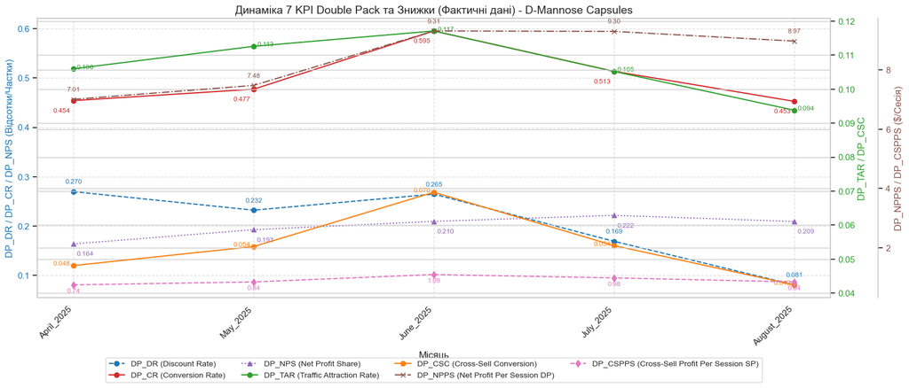

```
--- ЗВЕДЕНА ТАБЛИЦЯ: Помісячні KPI ---
```

| Month_Year Metric | April_2025 | May_2025 | June_2025 | July_2025 | August_2025 |
| --- | --- | --- | --- | --- | --- |
| DP_DR | 0.2698 | 0.2323 | 0.2648 | 0.1693 | 0.0811 |
| DP_CR | 0.4542 | 0.4772 | 0.5951 | 0.5134 | 0.4527 |
| DP_TAR | 0.1060 | 0.1126 | 0.1171 | 0.1052 | 0.0938 |
| DP_CSC | 0.0481 | 0.0537 | 0.0697 | 0.0540 | 0.0425 |
| DP_NPS | 0.1640 | 0.1928 | 0.2096 | 0.2219 | 0.2094 |
| DP_NPPS | 7.0071 | 7.4771 | 9.3150 | 9.3001 | 8.9725 |
| DP_CSPPS | 0.7424 | 0.8416 | 1.0905 | 0.9782 | 0.8415 |

### КРОК 3: Метод-А-DP_CR

#### Таблиця показників та формул

[output not shown]

**Алгоритм виконання розрахунків (Інструкція)**

Алгоритм виконує оптимізацію знижки ($DP\_DR$) для максимізації чистого прибутку ($Net\_Profit\_DP$) на основі поліноміальної регресії 3-го порядку:

1. **Формування Датасету (Крок 2):**
   - Дані $\text{Sessions, Units Ordered, Product Costs, Net Profit, Actual Price}$ для даблпаку (з Кроку 1) та $\text{DP\_DR, DP\_CR}$ (з Кроку 2) збираються в єдиний датасет.
   - Додається показник $\text{Unit\_Costs\_DP}$ (помісячна собівартість одиниці).
   - Датасет трансформується: місяці — колонки, показники (8 рядків, включаючи $Unit\_Costs\_DP$) — рядки.
2. **Розрахунок Констант та Меж (Крок 3.1):**
   - Обчислюються константи: $\text{month\_count}$, $\text{Sessions\_DP\_Avg}$, $\text{Unit\_Costs\_DP\_Avg}$, $\text{St\_Dev\_DP\_DR}$, $\text{min\_DP\_DR}$, $\text{max\_DP\_DR}$.
   - Визначаються межі оптимізації $\text{def\_Bound\_DP\_DR}$ шляхом відступу $\pm \text{St\_Dev\_DP\_DR}$ від історичних min/max значень $DP\_DR$, з обмеженням мінімальної межі до $0$.
3. **Побудова Регресії (Крок 3.2):**
   - Будується поліноміальна регресія **3-го порядку** для $\text{DP\_CR}(\text{DP\_DR})$, $\text{Actual\_Price\_DP}(\text{DP\_DR})$ та $\text{Sessions\_DP}(\text{DP\_DR})$.
   - Розраховується $R^2$ для кожної регресії.
   - **Перевірка трафіку:** Якщо $R^2 \le 0.1$ для $\text{Sessions\_DP}(\text{DP\_DR})$, в кінцевій формулі замість регресії використовується $\text{Sessions\_DP\_Avg}$.
4. **Оцінка Похибки та Оптимізація (Крок 4):**
   - Визначається функція прибутковості: $\text{Net\_Profit\_DP} = \text{Sessions} \times \text{DP\_CR} \times (\text{Actual\_Price} - \text{Unit\_Costs\_DP\_Avg})$.
   - **Оцінюється якість моделі:** Розраховується **$\text{MAPE}$** та **$\text{RMSE}$** шляхом порівняння значень $\text{Net\_Profit\_DP}$ (отриманих моделлю) з $\text{Net\_Profit\_DP}$ (історичними даними) для всіх історичних точок.
   - За допомогою функції $\text{minimize\_scalar}$ (метод 'bounded') шукається $\text{optimal\_dp\_dr}$, який максимізує $\text{Net\_Profit\_DP}$ у межах $\text{def\_Bound\_DP\_DR}$.
5. **Візуалізація (Крок 5):**
   - Виводяться 3 графіки регресійних кривих та фінальний графік кривої прибутковості, історичних точок та знайденої оптимальної точки. На графіках пунктиром показані межі $\text{def\_Bound\_DP\_DR}$.
6. **Звітність (Кроки 6-7):**
   - Знайдений $\text{optimal\_dp\_dr}$ та розрахований $\text{MAPE}$ зберігаються у словник $\text{ALL\_METHODS\_RESULTS}$ під ключами $\text{Product Name - Method-A-DP\_CR - DP\_DR}$ та $\text{Product Name - Method-A-DP\_CR - MAPE}$ відповідно.
   - Вся сервісна інформація (**включаючи $\text{MAPE}$ та $\text{RMSE}$**) виводиться у текстовому форматі.

```
--- 1. ДАТАСЕТ ДЛЯ АНАЛІЗУ ---
```

| Month_Year Metric | April_2025 | May_2025 | June_2025 | July_2025 | August_2025 |
| --- | --- | --- | --- | --- | --- |
| Sessions_DP | 1255.0000 | 1580.0000 | 1109.0000 | 1716.0000 | 1880.0000 |
| Units_Ordered_DP | 570.0000 | 754.0000 | 660.0000 | 881.0000 | 851.0000 |
| Product_Costs_DP | 9283.7400 | 12312.5800 | 10775.7000 | 14766.8000 | 14520.3200 |
| Net_Profit_DP | 8793.8600 | 11813.8200 | 10330.3000 | 15959.0000 | 16868.2800 |
| Actual_Price_DP | 31.7151 | 31.9979 | 31.9788 | 34.8760 | 36.8844 |
| Unit_Costs_DP | 16.2873 | 16.3297 | 16.3268 | 16.7614 | 17.0627 |
| DP_DR | 0.2698 | 0.2323 | 0.2648 | 0.1693 | 0.0811 |
| DP_CR | 0.4542 | 0.4772 | 0.5951 | 0.5134 | 0.4527 |

```
----------------------------------------------------------------------
--- 2. СЕРВІСНА ІНФОРМАЦІЯ: РОЗРАХУНОК КОНСТАНТ ТА МЕЖ ---
month_count: 5
Sessions_DP_Avg: 1508.0000
Unit_Costs_DP_Avg: 16.5929
St_Dev_DP_DR: 0.0396
min_DP_DR: 0.0811
max_DP_DR: 0.2698
def_Bound_DP_DR: [0.0414; 0.3095]
----------------------------------------------------------------------
--- 3. СЕРВІСНА ІНФОРМАЦІЯ: РЕГРЕСІЯ 3-ГО ПОРЯДКУ ---
Регресійний поліном DP_CR(DP_DR) = 69.3946x^3-38.9205x^2+6.9806x+0.1060. Детермінація R_2 = 0.2013
Регресійний поліном Actual_Price_DP(DP_DR) = 2879.2217x^3-1534.3870x^2+220.3141x+27.5747. Детермінація R_2 = 0.9969
Регресійний поліном Sessions_DP(DP_DR) = -372533.3295x^3+173496.2167x^2-26976.8883x+3124.5713. Детермінація R_2 = 0.9397

Заміна Sessions_DP(DP_DR) на Sessions_DP_Avg: ні
Формула прибутковості Net_Profit_DP = Sessions_DP(DP_DR) * DP_CR(DP_DR) * (Actual_Price_DP(DP_DR) - Unit_Costs_DP_Avg)
----------------------------------------------------------------------
```

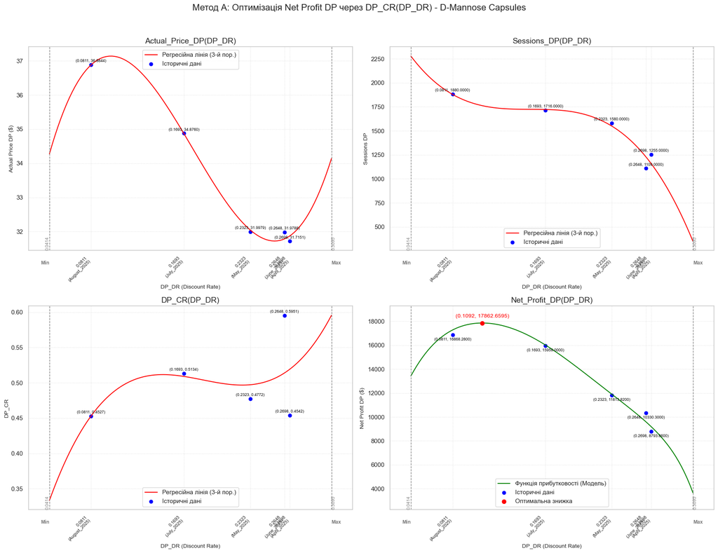

```
--- 6. СЕРВІСНА ІНФОРМАЦІЯ: РЕЗУЛЬТАТ ОПТИМІЗАЦІЇ ---
Оптимальна координата: (0.1092, 17862.6595)
Рекомендована знижка: 0.1092
Прогнозований профіт: 17862.6595
Похибка методу (MAPE): 0.0305
Похибка методу (RMSE): 418.8472
----------------------------------------------------------------------
--- 7. СЕРВІСНА ІНФОРМАЦІЯ: ЗБЕРЕЖЕННЯ ---
Успішний запис даних в ALL_METHODS_RESULTS:
- D-Mannose Capsules - Method-A-DP_CR - DP_DR: 0.1092
- D-Mannose Capsules - Method-A-DP_CR - MAPE: 0.0305
----------------------------------------------------------------------
```

### КРОК 4: Метод-B-DP_TAR

#### Таблиця показників та формул

[output not shown]

**Алгоритм виконання розрахунків (Інструкція)**

Алгоритм виконує оптимізацію знижки ($DP\_DR$) для максимізації чистого прибутку ($Net\_Profit\_DP$) на основі поліноміальної регресії 3-го порядку:

1. **Формування Датасету (Крок 2):**
   - Дані $\text{Sessions\_SP, Units Ordered\_DP, Product Costs\_DP, Net Profit\_DP, Actual Price\_DP}$ (з Кроку 1) та $\text{DP\_DR, DP\_CR, DP\_TAR}$ (з Кроку 2) збираються в єдиний датасет.
   - Додається показник $\text{Unit\_Costs\_DP}$ (помісячна собівартість одиниці).
   - Датасет трансформується: місяці — колонки, показники (9 рядків) — рядки.
2. **Розрахунок Констант та Меж (Крок 4.1):**
   - Обчислюються константи: $\text{month\_count}$, $\text{Sessions\_SP\_Avg}$ (ключова константа), $\text{Unit\_Costs\_DP\_Avg}$, $\text{St\_Dev\_DP\_DR}$, $\text{min\_DP\_DR}$, $\text{max\_DP\_DR}$.
   - Визначаються межі оптимізації $\text{def\_Bound\_DP\_DR}$ шляхом відступу $\pm \text{St\_Dev\_DP\_DR}$ від історичних min/max значень $DP\_DR$, з обмеженням мінімальної межі до $0$.
3. **Побудова Регресії (Крок 4.2):**
   - Будується поліноміальна регресія **3-го порядку** для $\text{DP\_TAR}(\text{DP\_DR})$, $\text{DP\_CR}(\text{DP\_DR})$ та $\text{Actual\_Price\_DP}(\text{DP\_DR})$.
   - Розраховується $R^2$ для кожної регресії.
4. **Оцінка Похибки та Оптимізація (Крок 4.3):**
   - Визначається складена функція прибутковості: $\text{Net\_Profit\_DP} = \text{Sessions\_SP\_Avg} \times \text{DP\_TAR}(\text{DP\_DR}) \times \text{DP\_CR}(\text{DP\_DR}) \times (\text{Actual\_Price\_DP}(\text{DP\_DR}) - \text{Unit\_Costs\_DP\_Avg})$.
   - **Оцінюється якість моделі:** Розраховується **$\text{MAPE}$** та **$\text{RMSE}$** шляхом порівняння значень $\text{Net\_Profit\_DP}$ (отриманих моделлю) з $\text{Net\_Profit\_DP}$ (історичними даними) для всіх історичних точок.
   - За допомогою функції $\text{minimize\_scalar}$ (метод 'bounded') шукається $\text{optimal\_dp\_dr}$, який максимізує $\text{Net\_Profit\_DP}$ у межах $\text{def\_Bound\_DP\_DR}$.
5. **Візуалізація (Крок 4.4):**
   - Виводяться 3 графіки регресійних кривих та фінальний графік кривої прибутковості, історичних точок та знайденої оптимальної точки. На графіках пунктиром показані межі $\text{def\_Bound\_DP\_DR}$.
6. **Звітність (Кроки 6-7):**
   - Знайдений $\text{optimal\_dp\_dr}$ та розрахований $\text{MAPE}$ зберігаються у словник $\text{ALL\_METHODS\_RESULTS}$ під ключами $\text{Product Name - Method-B-DP\_TAR - DP\_DR}$ та $\text{Product Name - Method-B-DP\_TAR - MAPE}$ відповідно.
   - Вся сервісна інформація (**включаючи $\text{MAPE}$ та $\text{RMSE}$**) виводиться у текстовому форматі.

```
--- 1. ДАТАСЕТ ДЛЯ АНАЛІЗУ ---
```

| Month_Year Metric | April_2025 | May_2025 | June_2025 | July_2025 | August_2025 |
| --- | --- | --- | --- | --- | --- |
| Sessions_SP | 11845.0000 | 14038.0000 | 9473.0000 | 16315.0000 | 20046.0000 |
| Units_Ordered_DP | 570.0000 | 754.0000 | 660.0000 | 881.0000 | 851.0000 |
| Product_Costs_DP | 9283.7400 | 12312.5800 | 10775.7000 | 14766.8000 | 14520.3200 |
| Net_Profit_DP | 8793.8600 | 11813.8200 | 10330.3000 | 15959.0000 | 16868.2800 |
| Actual_Price_DP | 31.7151 | 31.9979 | 31.9788 | 34.8760 | 36.8844 |
| Unit_Costs_DP | 16.2873 | 16.3297 | 16.3268 | 16.7614 | 17.0627 |
| DP_CR | 0.4542 | 0.4772 | 0.5951 | 0.5134 | 0.4527 |
| DP_TAR | 0.1060 | 0.1126 | 0.1171 | 0.1052 | 0.0938 |
| DP_DR | 0.2698 | 0.2323 | 0.2648 | 0.1693 | 0.0811 |

```
----------------------------------------------------------------------
--- 2. СЕРВІСНА ІНФОРМАЦІЯ: РОЗРАХУНОК КОНСТАНТ ТА МЕЖ ---
month_count: 5
Sessions_SP_Avg: 14343.4000
Unit_Costs_DP_Avg: 16.5929
St_Dev_DP_DR: 0.0396
min_DP_DR: 0.0811
max_DP_DR: 0.2698
def_Bound_DP_DR: [0.0414; 0.3095]
----------------------------------------------------------------------
--- 3. СЕРВІСНА ІНФОРМАЦІЯ: РЕГРЕСІЯ 3-ГО ПОРЯДКУ ---
Регресійний поліном DP_TAR(DP_DR) = -13.1405x^3+6.4641x^2-0.8497x+0.1272. Детермінація R_2 = 0.8291
Регресійний поліном DP_CR(DP_DR) = 69.3946x^3-38.9205x^2+6.9806x+0.1060. Детермінація R_2 = 0.2013
Регресійний поліном Actual_Price_DP(DP_DR) = 2879.2217x^3-1534.3870x^2+220.3141x+27.5747. Детермінація R_2 = 0.9969

Формула прибутковості Net_Profit_DP = Sessions_SP_Avg * DP_TAR(DP_DR) * DP_CR(DP_DR) * (Actual_Price_DP(DP_DR) - Unit_Costs_DP_Avg)
----------------------------------------------------------------------
```

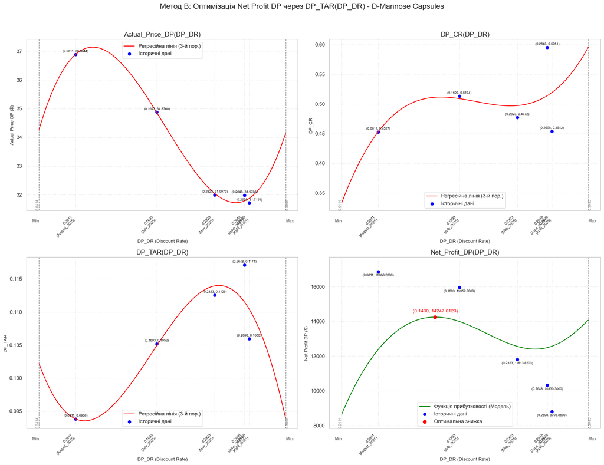

```
--- 6. СЕРВІСНА ІНФОРМАЦІЯ: РЕЗУЛЬТАТ ОПТИМІЗАЦІЇ ---
Оптимальна координата: (0.1430, 14247.0123)
Рекомендована знижка: 0.1430
Прогнозований профіт: 14247.0123
Похибка методу (MAPE): 0.2179
Похибка методу (RMSE): 2948.3136
----------------------------------------------------------------------
--- 7. СЕРВІСНА ІНФОРМАЦІЯ: ЗБЕРЕЖЕННЯ ---
Успішний запис даних в ALL_METHODS_RESULTS:
- D-Mannose Capsules - Method-B-DP_TAR - DP_DR: 0.1430
- D-Mannose Capsules - Method-B-DP_TAR - MAPE: 0.2179
----------------------------------------------------------------------
```

### КРОК 5: Метод-C-DP_CSC

#### Ключовий показник та формула прибутковості

| Змінна/Показник | Розшифровка | Регресійна модель / Формула розрахунку прибутковості |
| --- | --- | --- |
| **$DP\_CSC$** | Cross-Sell Conversion (крос-конверсія) | $\text{DP\_CSC}(\text{DP\_DR})$ **(Поліноміальна регресія 3-го порядку)** |
| **$Actual\_Price\_DP$** | Фактична ціна Double Pack | $\text{Actual\_Price\_DP}(\text{DP\_DR})$ **(Поліноміальна регресія 3-го порядку)** |
| **$Net\_Profit\_DP$** | Чистий прибуток Double Pack (функція оптимізації) | $$\text{Net\_Profit\_DP} = \text{Sessions\_SP\_Avg} \times \mathbf{DP\_CSC(DP\_DR)} \times (\mathbf{Actual\_Price\_DP(DP\_DR)} - \text{Unit\_Costs\_DP\_Avg})$$ |

**Алгоритм виконання розрахунків**

Алгоритм виконує оптимізацію знижки ($DP\_DR$) для максимізації чистого прибутку ($Net\_Profit\_DP$) на основі складеної функції, що використовує поліноміальну регресію 3-го порядку для моделювання ключових показників:

1. **Побудова Регресії:** Будуються моделі $\text{DP\_CSC}(\text{DP\_DR})$ та $\text{Actual\_Price\_DP}(\text{DP\_DR})$.
2. **Складена Функція Профіту:** Використовується наведена вище формула, де $\mathbf{DP\_CSC(DP\_DR)}$ та $\mathbf{Actual\_Price\_DP(DP\_DR)}$ є регресійними функціями, а $\text{Sessions\_SP\_Avg}$ та $\text{Unit\_Costs\_DP\_Avg}$ — константи.
3. **Оптимізація:** За допомогою функції $\text{minimize\_scalar}$ шукається $\text{optimal\_dp\_dr}$, який максимізує $\text{Net\_Profit\_DP}$ у визначених межах $\text{def\_Bound\_DP\_DR}$.
4. **Оцінка Якості:** Розраховується **$\text{MAPE}$** та **$\text{RMSE}$** шляхом порівняння значень $\text{Net\_Profit\_DP}$ моделі з історичними даними.
5. **Візуалізація та Звітність:** Виводяться графіки та кінцевий результат ($\text{optimal\_dp\_dr}$) та метрики якості моделі ($\text{MAPE}, \text{RMSE}$).

```
--- 1. ДАТАСЕТ ДЛЯ АНАЛІЗУ ---
```

| Month_Year Metric | April_2025 | May_2025 | June_2025 | July_2025 | August_2025 |
| --- | --- | --- | --- | --- | --- |
| Sessions_SP | 11845.0000 | 14038.0000 | 9473.0000 | 16315.0000 | 20046.0000 |
| Units_Ordered_DP | 570.0000 | 754.0000 | 660.0000 | 881.0000 | 851.0000 |
| Product_Costs_DP | 9283.7400 | 12312.5800 | 10775.7000 | 14766.8000 | 14520.3200 |
| Net_Profit_DP | 8793.8600 | 11813.8200 | 10330.3000 | 15959.0000 | 16868.2800 |
| Actual_Price_DP | 31.7151 | 31.9979 | 31.9788 | 34.8760 | 36.8844 |
| Unit_Costs_DP | 16.2873 | 16.3297 | 16.3268 | 16.7614 | 17.0627 |
| DP_CSC | 0.0481 | 0.0537 | 0.0697 | 0.0540 | 0.0425 |
| DP_DR | 0.2698 | 0.2323 | 0.2648 | 0.1693 | 0.0811 |

```
----------------------------------------------------------------------
--- 2. СЕРВІСНА ІНФОРМАЦІЯ: РОЗРАХУНОК КОНСТАНТ ТА МЕЖ ---
month_count: 5
Sessions_SP_Avg: 14343.4000
Unit_Costs_DP_Avg: 16.5929
St_Dev_DP_DR: 0.0396
min_DP_DR: 0.0811
max_DP_DR: 0.2698
def_Bound_DP_DR: [0.0414; 0.3095]
----------------------------------------------------------------------
--- 3. СЕРВІСНА ІНФОРМАЦІЯ: РЕГРЕСІЯ 3-ГО ПОРЯДКУ ---
Регресійний поліном DP_CSC(DP_DR) = 1.1700x^3-1.0265x^2+0.3224x+0.0225. Детермінація R_2 = 0.4016
Регресійний поліном Actual_Price_DP(DP_DR) = 2879.2217x^3-1534.3870x^2+220.3141x+27.5747. Детермінація R_2 = 0.9969

Формула прибутковості Net_Profit_DP = Sessions_SP_Avg * DP_CSC(DP_DR) * (Actual_Price_DP(DP_DR) - Unit_Costs_DP_Avg)
----------------------------------------------------------------------
```

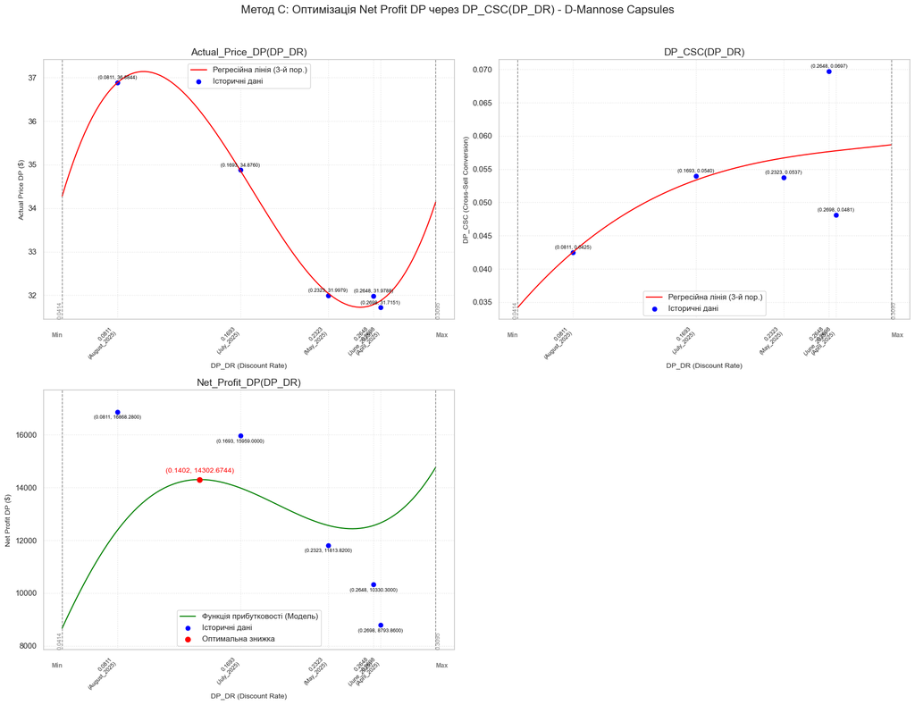

```
--- 6. СЕРВІСНА ІНФОРМАЦІЯ: РЕЗУЛЬТАТ ОПТИМІЗАЦІЇ ---
Оптимальна координата: (0.1402, 14302.6744)
Рекомендована знижка: 0.1402
Прогнозований профіт: 14302.6744
Похибка методу (MAPE): 0.2217
Похибка методу (RMSE): 2983.8457
----------------------------------------------------------------------
--- 7. СЕРВІСНА ІНФОРМАЦІЯ: ЗБЕРЕЖЕННЯ ---
Успішний запис даних в ALL_METHODS_RESULTS:
- D-Mannose Capsules - Method-C-DP_CSC - DP_DR: 0.1402
- D-Mannose Capsules - Method-C-DP_CSC - MAPE: 0.2217
----------------------------------------------------------------------
```

### КРОК 6: Метод-D-DP_NPS

#### Ключові показники та Формула прибутковості

| Змінна/Показник | Розшифровка | Формула / Модель |
| --- | --- | --- |
| **$DP\_NPS$** | Net Profit Share (Частка прибутку DP від загального) | $\text{DP\_NPS} = \frac{\text{Net\_Profit\_DP}}{\text{Net\_Profit\_SP} + \text{Net\_Profit\_DP}}$ |
| **$DP\_DR$** | Discount Rate (Коефіцієнт знижки) | $\text{DP\_DR}$ **(Незалежна змінна)** |
| **$Net\_Profit\_Total\_Avg$** | Середній історичний чистий прибуток (SP + DP) | $\text{Net\_Profit\_Total\_Avg} = \text{MEAN}(\text{Net\_Profit\_Total})$ |
| **$Net\_Profit\_DP$** | Чистий прибуток Double Pack (функція оптимізації) | $$\text{Net\_Profit\_DP} = \mathbf{Net\_Profit\_Total\_Avg} \times \mathbf{DP\_NPS}(\text{DP\_DR})$$ |

**Алгоритм виконання розрахунків**

Алгоритм виконує оптимізацію знижки ($DP\_DR$) для максимізації чистого прибутку ($Net\_Profit\_DP$) на основі моделювання частки прибутковості (DP_NPS):

1. **Розрахунок Констант:** Обчислюється ключова константа $\text{Net\_Profit\_Total\_Avg}$ та межі оптимізації $\text{def\_Bound\_DP\_DR}$.
2. **Побудова Регресії:** Будується поліноміальна регресія **3-го порядку** для $\mathbf{DP\_NPS}(\text{DP\_DR})$.
3. **Складена Функція Профіту:** Використовується наведена вище формула, де $\mathbf{DP\_NPS}(\text{DP\_DR})$ є регресійною функцією, а $\text{Net\_Profit\_Total\_Avg}$ — константа.
4. **Оптимізація:** За допомогою функції $\text{minimize\_scalar}$ шукається $\text{optimal\_dp\_dr}$, який максимізує $\text{Net\_Profit\_DP}$ у межах $\text{def\_Bound\_DP\_DR}$.
5. **Оцінка Якості:** Розраховується **$\text{MAPE}$** та **$\text{RMSE}$** шляхом порівняння значень $\text{Net\_Profit\_DP}$ моделі з історичними даними.
6. **Звітність:** Виводяться графіки та кінцевий результат ($\text{optimal\_dp\_dr}$) та метрики якості моделі ($\text{MAPE}, \text{RMSE}$).

```
--- 1. ДАТАСЕТ ДЛЯ АНАЛІЗУ ---
```

| Month_Year Metric | April_2025 | May_2025 | June_2025 | July_2025 | August_2025 |
| --- | --- | --- | --- | --- | --- |
| Net_Profit_SP | 44841.9035 | 49467.8560 | 38951.0760 | 55975.0550 | 63701.5390 |
| Net_Profit_DP | 8793.8600 | 11813.8200 | 10330.3000 | 15959.0000 | 16868.2800 |
| Net_Profit_Total | 53635.7635 | 61281.6760 | 49281.3760 | 71934.0550 | 80569.8190 |
| DP_DR | 0.2698 | 0.2323 | 0.2648 | 0.1693 | 0.0811 |
| DP_NPS | 0.1640 | 0.1928 | 0.2096 | 0.2219 | 0.2094 |

```
----------------------------------------------------------------------
--- 2. СЕРВІСНА ІНФОРМАЦІЯ: РОЗРАХУНОК КОНСТАНТ ТА МЕЖ ---
month_count: 5
Net_Profit_Total_Avg: 63340.5379
St_Dev_DP_DR: 0.0396
min_DP_DR: 0.0811
max_DP_DR: 0.2698
def_Bound_DP_DR: [0.0414; 0.3095]
----------------------------------------------------------------------
--- 3. СЕРВІСНА ІНФОРМАЦІЯ: РЕГРЕСІЯ 3-ГО ПОРЯДКУ ---
Регресійний поліном DP_NPS(DP_DR) = 13.1111x^3-9.4424x^2+1.8474x+0.1148. Детермінація R_2 = 0.4999

Формула прибутковості Net_Profit_DP = Net_Profit_Total_Avg * DP_NPS(DP_DR)
----------------------------------------------------------------------
```

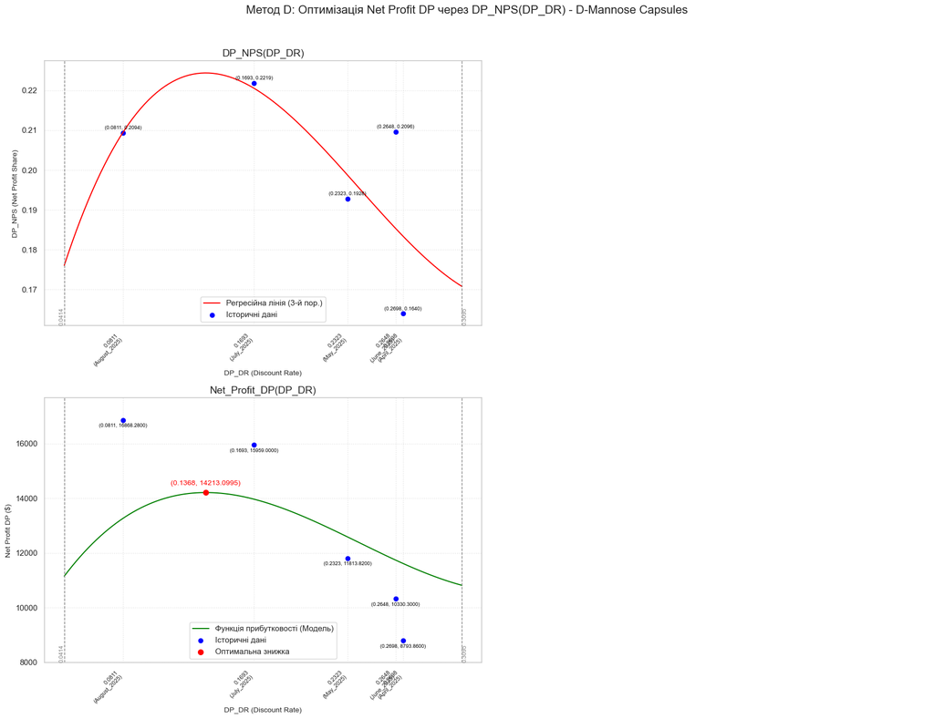

```
--- 6. СЕРВІСНА ІНФОРМАЦІЯ: РЕЗУЛЬТАТ ОПТИМІЗАЦІЇ ---
Оптимальна координата: (0.1368, 14213.0995)
Рекомендована знижка: 0.1368
Прогнозований профіт: 14213.0995
Похибка методу (MAPE): 0.1722
Похибка методу (RMSE): 2343.2310
----------------------------------------------------------------------
--- 7. СЕРВІСНА ІНФОРМАЦІЯ: ЗБЕРЕЖЕННЯ ---
Успішний запис даних в ALL_METHODS_RESULTS:
- D-Mannose Capsules - Method-D-DP_NPS - DP_DR: 0.1368
- D-Mannose Capsules - Method-D-DP_NPS - MAPE: 0.1722
----------------------------------------------------------------------
```

### КРОК 7: Метод-E-DP_NPPS

#### Ключові показники та Формула прибутковості

| Змінна/Показник | Розшифровка | Формула / Модель |
| --- | --- | --- |
| **$DP\_NPPS$** | Net Profit Per Session DP (Чистий прибуток на одну сесію DP) | $\text{DP\_NPPS} = \frac{\text{Net\_Profit\_DP}}{\text{Sessions\_DP}}$ |
| **$DP\_DR$** | Discount Rate (Коефіцієнт знижки) | $\text{DP\_DR}$ **(Незалежна змінна)** |
| **$Sessions\_DP\_Avg$** | Середня історична кількість сесій DP | $\text{Sessions\_DP\_Avg} = \text{MEAN}(\text{Sessions\_DP})$ |
| **$Net\_Profit\_DP$** | Чистий прибуток Double Pack (функція оптимізації) | $$\text{Net\_Profit\_DP} = \mathbf{Sessions\_DP\_Avg} \times \mathbf{DP\_NPPS}(\text{DP\_DR})$$ |

**Алгоритм виконання розрахунків (Стисло)**

Алгоритм виконує оптимізацію знижки ($DP\_DR$) для максимізації чистого прибутку ($Net\_Profit\_DP$) на основі моделювання прибутковості трафіку:

1. **Розрахунок Констант:** Обчислюється ключова константа $\text{Sessions\_DP\_Avg}$ та межі оптимізації $\text{def\_Bound\_DP\_DR}$.
2. **Побудова Регресії:** Будується поліноміальна регресія **3-го порядку** для $\mathbf{DP\_NPPS}(\text{DP\_DR})$.
3. **Складена Функція Профіту:** Використовується наведена вище формула, де $\mathbf{DP\_NPPS}(\text{DP\_DR})$ є регресійною функцією, а $\text{Sessions\_DP\_Avg}$ — константа.
4. **Оптимізація:** За допомогою функції $\text{minimize\_scalar}$ шукається $\text{optimal\_dp\_dr}$, який максимізує $\text{Net\_Profit\_DP}$ у межах $\text{def\_Bound\_DP\_DR}$.
5. **Оцінка Якості:** Розраховується **$\text{MAPE}$** та **$\text{RMSE}$** шляхом порівняння значень $\text{Net\_Profit\_DP}$ моделі з історичними даними.
6. **Звітність:** Виводяться графіки та кінцевий результат ($\text{optimal\_dp\_dr}$) та метрики якості моделі ($\text{MAPE}, \text{RMSE}$).

```
--- 1. ДАТАСЕТ ДЛЯ АНАЛІЗУ ---
```

| Month_Year Metric | April_2025 | May_2025 | June_2025 | July_2025 | August_2025 |
| --- | --- | --- | --- | --- | --- |
| Net_Profit_DP | 8793.8600 | 11813.8200 | 10330.3000 | 15959.0000 | 16868.2800 |
| Sessions_DP | 1255.0000 | 1580.0000 | 1109.0000 | 1716.0000 | 1880.0000 |
| DP_DR | 0.2698 | 0.2323 | 0.2648 | 0.1693 | 0.0811 |
| DP_NPPS | 7.0071 | 7.4771 | 9.3150 | 9.3001 | 8.9725 |

```
----------------------------------------------------------------------
--- 2. СЕРВІСНА ІНФОРМАЦІЯ: РОЗРАХУНОК КОНСТАНТ ТА МЕЖ ---
month_count: 5
Sessions_DP_Avg: 1508.0000
St_Dev_DP_DR: 0.0396
min_DP_DR: 0.0811
max_DP_DR: 0.2698
def_Bound_DP_DR: [0.0414; 0.3095]
----------------------------------------------------------------------
--- 3. СЕРВІСНА ІНФОРМАЦІЯ: РЕГРЕСІЯ 3-ГО ПОРЯДКУ ---
Регресійний поліном DP_NPPS(DP_DR) = 2461.7461x^3-1355.5078x^2+221.6579x-1.3924. Детермінація R_2 = 0.3473

Формула прибутковості Net_Profit_DP = Sessions_DP_Avg * DP_NPPS(DP_DR)
----------------------------------------------------------------------
```

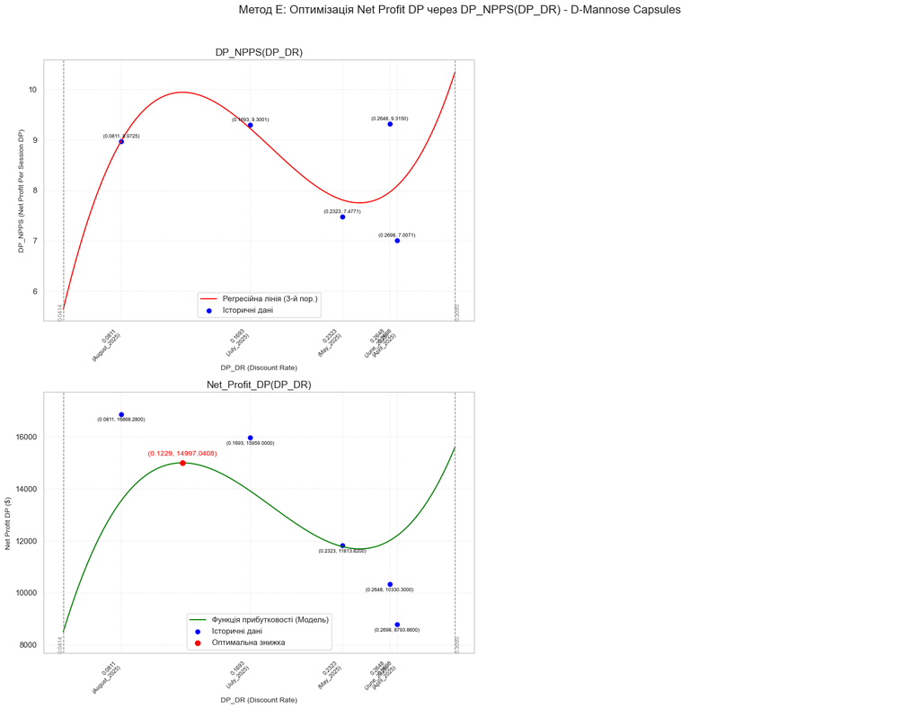

```
--- 6. СЕРВІСНА ІНФОРМАЦІЯ: РЕЗУЛЬТАТ ОПТИМІЗАЦІЇ ---
Оптимальна координата: (0.1229, 14997.0408)
Рекомендована знижка: 0.1229
Прогнозований профіт: 14997.0408
Похибка методу (MAPE): 0.1756
Похибка методу (RMSE): 2434.8299
----------------------------------------------------------------------
--- 7. СЕРВІСНА ІНФОРМАЦІЯ: ЗБЕРЕЖЕННЯ ---
Успішний запис даних в ALL_METHODS_RESULTS:
- D-Mannose Capsules - Method-E-DP_NPPS - DP_DR: 0.1229
- D-Mannose Capsules - Method-E-DP_NPPS - MAPE: 0.1756
----------------------------------------------------------------------
```

### КРОК 8: Метод-F-DP_CSPPS

#### Ключові показники та Формула прибутковості

| Змінна/Показник | Розшифровка | Формула / Модель |
| --- | --- | --- |
| **$DP\_CSPPS$** | Cross-Sell Profit Per Session SP (Чистий прибуток DP на одну сесію SP) | $\text{DP\_CSPPS} = \frac{\text{Net\_Profit\_DP}}{\text{Sessions\_SP}}$ |
| **$DP\_DR$** | Discount Rate (Коефіцієнт знижки) | $\text{DP\_DR}$ **(Незалежна змінна)** |
| **$Sessions\_SP\_Avg$** | Середня історична кількість сесій SP | $\text{Sessions\_SP\_Avg} = \text{MEAN}(\text{Sessions\_SP})$ |
| **$Net\_Profit\_DP$** | Чистий прибуток Double Pack (функція оптимізації) | $$\text{Net\_Profit\_DP} = \mathbf{Sessions\_SP\_Avg} \times \mathbf{DP\_CSPPS}(\text{DP\_DR})$$ |

**Алгоритм виконання розрахунків (Стисло)**

Алгоритм виконує оптимізацію знижки ($DP\_DR$) для максимізації чистого прибутку ($Net\_Profit\_DP$) на основі моделювання ефективності крос-продажів:

1. **Розрахунок Констант:** Обчислюється ключова константа $\text{Sessions\_SP\_Avg}$ та межі оптимізації $\text{def\_Bound\_DP\_DR}$.
2. **Побудова Регресії:** Будується поліноміальна регресія **3-го порядку** для $\mathbf{DP\_CSPPS}(\text{DP\_DR})$.
3. **Складена Функція Профіту:** Використовується наведена вище формула, де $\mathbf{DP\_CSPPS}(\text{DP\_DR})$ є регресійною функцією, а $\text{Sessions\_SP\_Avg}$ — константа.
4. **Оптимізація:** За допомогою функції $\text{minimize\_scalar}$ шукається $\text{optimal\_dp\_dr}$, який максимізує $\text{Net\_Profit\_DP}$ у межах $\text{def\_Bound\_DP\_DR}$.
5. **Оцінка Якості:** Розраховується **$\text{MAPE}$** та **$\text{RMSE}$** шляхом порівняння значень $\text{Net\_Profit\_DP}$ моделі з історичними даними.
6. **Звітність:** Виводяться графіки та кінцевий результат ($\text{optimal\_dp\_dr}$) та метрики якості моделі ($\text{MAPE}, \text{RMSE}$).

```
--- 1. ДАТАСЕТ ДЛЯ АНАЛІЗУ ---
```

| Month_Year Metric | April_2025 | May_2025 | June_2025 | July_2025 | August_2025 |
| --- | --- | --- | --- | --- | --- |
| Net_Profit_DP | 8793.8600 | 11813.8200 | 10330.3000 | 15959.0000 | 16868.2800 |
| Sessions_SP | 11845.0000 | 14038.0000 | 9473.0000 | 16315.0000 | 20046.0000 |
| DP_DR | 0.2698 | 0.2323 | 0.2648 | 0.1693 | 0.0811 |
| DP_CSPPS | 0.7424 | 0.8416 | 1.0905 | 0.9782 | 0.8415 |

```
----------------------------------------------------------------------
--- 2. СЕРВІСНА ІНФОРМАЦІЯ: РОЗРАХУНОК КОНСТАНТ ТА МЕЖ ---
month_count: 5
Sessions_SP_Avg: 14343.4000
St_Dev_DP_DR: 0.0396
min_DP_DR: 0.0811
max_DP_DR: 0.2698
def_Bound_DP_DR: [0.0414; 0.3095]
----------------------------------------------------------------------
--- 3. СЕРВІСНА ІНФОРМАЦІЯ: РЕГРЕСІЯ 3-ГО ПОРЯДКУ ---
Регресійний поліном DP_CSPPS(DP_DR) = 171.3023x^3-100.1764x^2+18.1107x-0.0585. Детермінація R_2 = 0.1078

Формула прибутковості Net_Profit_DP = Sessions_SP_Avg * DP_CSPPS(DP_DR)
----------------------------------------------------------------------
```

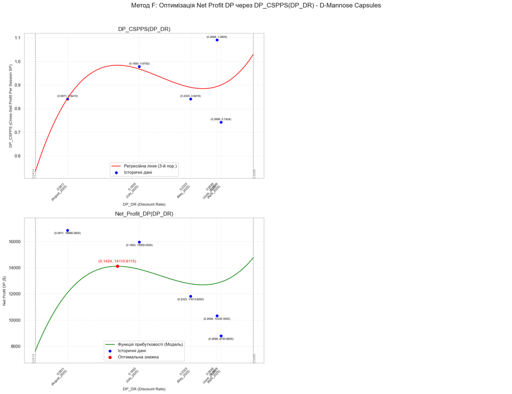

```
--- 6. СЕРВІСНА ІНФОРМАЦІЯ: РЕЗУЛЬТАТ ОПТИМІЗАЦІЇ ---
Оптимальна координата: (0.1424, 14110.6115)
Рекомендована знижка: 0.1424
Прогнозований профіт: 14110.6115
Похибка методу (MAPE): 0.2407
Похибка методу (RMSE): 3200.7557
----------------------------------------------------------------------
--- 7. СЕРВІСНА ІНФОРМАЦІЯ: ЗБЕРЕЖЕННЯ ---
Успішний запис даних в ALL_METHODS_RESULTS:
- D-Mannose Capsules - Method-F-DP_CSPPS - DP_DR: 0.1424
- D-Mannose Capsules - Method-F-DP_CSPPS - MAPE: 0.2407
----------------------------------------------------------------------
```

### КРОК 9: Метод-G-Net_Profit_DP_Reg

#### Ключові показники та Формула прибутковості

| Змінна/Показник | Розшифровка | Модель / Призначення |
| --- | --- | --- |
| **$Net\_Profit\_DP$** | Чистий прибуток Double Pack | $\text{Net\_Profit\_DP}$ **(Залежна змінна)** |
| **$DP\_DR$** | Discount Rate (Коефіцієнт знижки) | $\text{DP\_DR}$ **(Незалежна змінна)** |
| **$Net\_Profit\_DP_{\text{Reg}}$** | Регресійна функція прибутковості (оптимізації) | $$\text{Net\_Profit\_DP}_{\text{Reg}}(\text{DP\_DR}) = a \cdot \text{DP\_DR}^3 + b \cdot \text{DP\_DR}^2 + c \cdot \text{DP\_DR} + d$$ |

**Алгоритм виконання розрахунків (Стисло)**

Алгоритм виконує пряму оптимізацію знижки ($DP\_DR$) на основі моделювання історичного чистого прибутку, без використання проміжних показників:

1. **Підготовка даних:** Витягуються історичні значення $\text{Net\_Profit\_DP}$ та $\text{DP\_DR}$.
2. **Розрахунок меж:** Обчислюються межі оптимізації $\text{def\_Bound\_DP\_DR}$.
3. **Побудова Регресії:** Будується **пряма поліноміальна регресія 3-го порядку** $\text{Net\_Profit\_DP}_{\text{Reg}}(\text{DP\_DR})$. Ця функція одразу виступає функцією прибутковості.
4. **Оптимізація:** За допомогою функції $\text{minimize\_scalar}$ шукається $\text{optimal\_dp\_dr}$, який максимізує $\text{Net\_Profit\_DP}_{\text{Reg}}$ у межах $\text{def\_Bound\_DP\_DR}$.
5. **Оцінка Якості:** Розраховується **$\text{MAPE}$** та **$\text{RMSE}$** шляхом порівняння значень $\text{Net\_Profit\_DP}_{\text{Reg}}$ з історичними даними $\text{Net\_Profit\_DP}$.
6. **Звітність:** Виводяться графіки та кінцевий результат ($\text{optimal\_dp\_dr}$) та метрики якості моделі ($\text{MAPE}, \text{RMSE}$).

```
--- 1. ДАТАСЕТ ДЛЯ АНАЛІЗУ ---
```

| Month_Year Metric | April_2025 | May_2025 | June_2025 | July_2025 | August_2025 |
| --- | --- | --- | --- | --- | --- |
| Net_Profit_DP | 8793.8600 | 11813.8200 | 10330.3000 | 15959.0000 | 16868.2800 |
| DP_DR | 0.2698 | 0.2323 | 0.2648 | 0.1693 | 0.0811 |

```
----------------------------------------------------------------------
--- 2. СЕРВІСНА ІНФОРМАЦІЯ: РОЗРАХУНОК КОНСТАНТ ТА МЕЖ ---
month_count: 5
St_Dev_DP_DR: 0.0396
min_DP_DR: 0.0811
max_DP_DR: 0.2698
def_Bound_DP_DR: [0.0414; 0.3095]
----------------------------------------------------------------------
--- 3. СЕРВІСНА ІНФОРМАЦІЯ: РЕГРЕСІЯ 3-ГО ПОРЯДКУ ---
Регресійний поліном Net_Profit_DP(DP_DR) = 1392111.7829x^3-1015135.3949x^2+175259.0813x+8593.6702. Детермінація R_2 = 0.9850

Функція прибутковості Net_Profit_DP(DP_DR) = 1392111.7829x^3-1015135.3949x^2+175259.0813x+8593.6702
----------------------------------------------------------------------
```

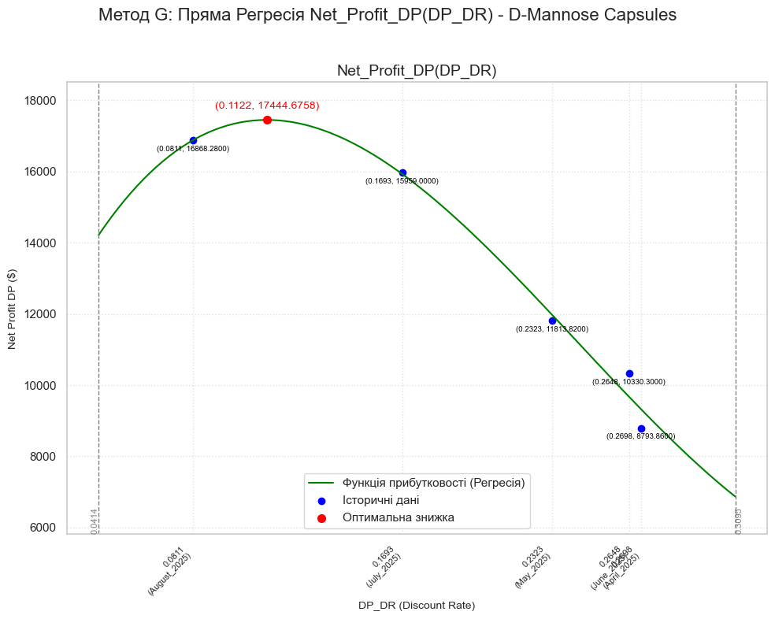

```
--- 6. СЕРВІСНА ІНФОРМАЦІЯ: РЕЗУЛЬТАТ ОПТИМІЗАЦІЇ ---
Оптимальна координата: (0.1122, 17444.6758)
Рекомендована знижка: 0.1122
Прогнозований профіт: 17444.6758
Похибка методу (MAPE): 0.0281
Похибка методу (RMSE): 385.6392
----------------------------------------------------------------------
--- 7. СЕРВІСНА ІНФОРМАЦІЯ: ЗБЕРЕЖЕННЯ ---
Успішний запис даних в ALL_METHODS_RESULTS:
- D-Mannose Capsules - Method-G-Net_Profit_DP_Reg - DP_DR: 0.1122
- D-Mannose Capsules - Method-G-Net_Profit_DP_Reg - MAPE: 0.0281
----------------------------------------------------------------------
```